# Time Series

Rachel Childers

```r
library(dagitty) #Library to create and analyze causal graphs
library(ggplot2) #Plotting
suppressWarnings(suppressMessages(library(ggdag))) #library to plot causal graphs
```

## Time Series Causal Inference

- Time series models describe data where samples are ordered in sequence
  - Quarterly macroeconomic aggregates like output and prices, monthly unemployment reports, a stock price every second, etc
- The index $t$ for observations $\{O_t\}_{t=1}^{T}$ is not arbitrary, but reflects statistical and causal structure
- Time series inference attempts to use historical behavior of data to learn about its properties
- This data type adds additional purely statistical complications
  - Observations typically *dependent*, so one can’t rely on results for independent samples
  - Dependence structure impacts estimation, inference
  - Even in the limit of infinite data, may not be able to learn probability distribution, making “identification” not always relevant
- Causal structure interacts with statistical structure, introducing additional challenges
  - Benefit of time ordering is that, barring time travel, causal order is restricted to be in direction of temporal order
  - Causal relationships between variables at different times may induce dependence, which may have different properties for observed and counterfactual variables
  - Estimation goal will often be to learn about these causal dependencies
- Today’s class will cover limited range of topics
- Will restrict most attention to cases where either finite sample inference is possible or limited dependence allows use of results that are “close” to the iid setting
  - Inferential results under strong dependence require a somewhat different statistical machinery
- Focus on acyclic models and causal estimands coming from a change in a single point in time
  - Cyclic models, with General Equilibrium interactions, and interventions to policies, require somewhat different modeling structure

## Example Applications

- Time series provide main source of data on outcomes where there may be no comparable units
  - Macroeconomic aggregates, market-level financial outcomes, geosciences, etc
- Source of information is instead historical behavior of same series
  - Comparison of macroeconomic policies in the 2010s to those in the 1930s, 40s, 50s
- Also useful for performing comparisons within a unit, if observed repeatedly
- Causal effects may be across variables at the same time, or across time
  - How does government spending affect future path of GDP?
  - How does a rate hike by the monetary authority affect output and prices?
- To obtain causal effects, will need some sources of variation in the policies which are random or “quasi-experimental”
- These may be historical accidents or idiosyncrasies not associated with other sources of variation
- As in cross-sectional case, helpful to have institutional and historical understanding of determinants of treatment
  - Ramey (2016) applications make use of detailed narrative record of fiscal and monetary policy-makers as well as statistical properties

## Time Series Statistical Properties

- $\{O_t\}_{t=1}^{T}$ is modeled as a *stochastic process*: a sequence of random variables indexed by $t$
- For any $t$, we refer to $O_{t-1}$ as the *lag* of $O_t$, and $O^{t}=(O_t,O_{t-1},O_{t-2},...)$ as the *history* of $O_t$ up to time $t$, and let $O_{s:t}=\{O_j\}_{j=s}^{t}$ denote the subsequence between s and t
- Our goal will often be to extrapolate from past to future values; for this we may rely on **stationarity**
  - A condition where historical patterns are assumed to be identical in distribution to patterns at other times.
- $\{O_t\}_{t=1}^{T}$ is (strictly) stationary if for any subsequence $\{O_{t_j}\}_{j=1}^{J}$ and any shift in time $h$, $P(\{O_{t_j}\}_{j=1}^{J})=P(\{O_{t_j-h}\}_{j=1}^{K})$
  - Only distance in time between two points affects distribution, not identity of time point
- Rules out trends up or down, shifts or breaks after which distribution changes, predictable seasonal changes, systematic changes in variability, etc
- Data may be stationary only after transformations to remove trends, seasons, breaks
  - If $Y_t=ct+\tilde{Y}_t$ for stationary $\tilde{Y}_t$, subtracting $ct$ is called “detrending” and may turn growing series into stable one
- Stationarity will allow us to say something about full series from only part of it
  - Can take $P(O_t)$ $E[O_t]$, $P(O_t|O^t)$, etc as quantities which do not depend on $t$
- Often also assume causal structure is time-invariant: DAG relating $O_t$ and $O^{t-1}$ does not depend on $t$
  - Implies time-invariant conditional distributions, which are necessary but not sufficient for statistical stationarity
  - For causal estimands, which depend on observed and counterfactual outcomes, will rely on stationarity of both

## Dependence and Limit Theorems

- In order to estimate distributions, would help to have versions of law of large numbers and central limit theorem
  - These require stationarity, but also limits on *dependence*
- To see why, consider series which is $(0,0,0,\ldots,)$ w/ prob. 1/2, and $(1,1,1,\ldots,)$ w/ prob. 1/2
  - This is stationary, with $E[O_t]=0.5$, but for all $T$, $\frac{1}{T}\sum_{t=1}^{T}O_t$ is $0$ w/ prob. 1/2, and $1$ w/ prob. 1/2, and so is bounded away from the mean almost surely
- A stochastic process which satisfies a law of large numbers $\frac{1}{T}\sum_{t=1}^{T}O_t\overset{p}{\to}E[O_t]$ is said to be **ergodic**
- In order to perform inference one usually asks for a stronger condition, which ensures that dependence over time decays to 0
- Let $\mathcal{F}_{s}^{t}$ be the space of events (sigma algebra) generated by $O_{s:t}$, $s$ or $t$ possibly infinite
- $\alpha(j):=\sup\{|P(A\cap B)-P(A)P(B)|:A\in\mathcal{F}_{-\infty}^{t}, B\in\mathcal{F}_{t+j}^{\infty}\}$ is the **$\alpha$-mixing coefficient** of order $j$
  - Value not dependent on $t$ if sequence stationary
  - If $\alpha(j)\to 0$ as $j\to\infty$, $O_t$ is said to be **$\alpha$-mixing** (or *strong mixing*, but that also gets used for a slightly different, related concept)
- Idea: as points get further separated in time, they are closer and closer to independent.
  - Different dependency measures yield slightly different but interrelated mixing conditions ($\beta,\rho,\phi$ etc mixing imply $\alpha$: see Bradley (2005))
- For our purposes, useful result from mixing is that coefficients bound covariances across time and ensure validity of a central limit theorem
- Primitive conditions implying ergodicity or mixing can be derived for many models of stochastic processes, but are by no means guaranteed
  - For linear process relationships, imposes restrictions on coefficients; for nonlinear case, on functional forms

## Inference For Time Series

- Let $Y_t$ be stationary and ergodic, with $E[|Y_t|^{2r}]<\infty$ for $r>1$ and $\alpha-$mixing with $\sum_{k}k^{\frac{1}{r-1}}\alpha(k)<\infty$
- Then we have a Time Series Central limit theorem: $\frac{1}{\sqrt{T}}\sum_{t=1}^{T}(Y_t-E[Y_t])\overset{d}{\rightarrow}N(0,\Sigma)$
- Where $\Sigma$ is the **Long run Variance**: the limit of the variance of the sum, equal to $\Sigma=\sum_{h=-\infty}^{\infty}Cov(Y_t,Y_{t+h})=Var(Y_t)+2\sum_{h=1}^{\infty}Cov(Y_t,Y_{t+h})$
  - Above conditions from Doukhan, Massart, and Rio (1994), though many minor variants exist: need at minimum to ensure long run variance is finite
- To estimate long run variance, can use (possibly kernel weighted) sum of sample (auto-)covariances $\widehat{Var}(Y_t)+2\sum_{h=1}^Tk(\frac{h}{S})\widehat{Cov}(Y_t,Y_{t+h})$
  - Newey and West (1987) variance estimates use $k(u)=(1-|u|)1\{u\leq 1\}$ and are implemented in most statistical software
  - Rule of thumb choice $S=0.75 T^{1/3}$ ensures consistency under (stronger) moment and mixing conditions
- Large but too-rarely-applied literature notes that estimation in error in $\Sigma$ is substantial, which complicates use, e.g. in t-statistics
  - Corrections to critical values based on refined asymptotics and alternate estimators can yield more accurate inference: see Lazarus et al. (2018) for a recent overview
- Alternate approaches to time series inference decompose the series into independent or conditionally independent components
- In the absence of stationarity and mixing, wide variety of limiting behaviors are possible
  - Well-studied case is integrated processes, whose *change* $Y_t-Y_{t-1}$ is stationary
  - Ubiquitous when working with asset prices, and anything linked to their levels, due (roughly) to the Fundamental Theorem of Asset Pricing
  - Deserves much more attention than I will give it, but a warning to use returns and not levels unless explicitly accounting for possible nonstationarity

## Point Interventions

- Goal is to measure the effect of a treatment variable $X_t$ at a point in time $t$ on an outcome variable $Y_{t+h}$ at some point $h\geq 0$ periods ahead
- Typically, one will want to measure effects as function of $h$ to trace out time path
  - Called the **Impulse Response Function** to the shock
- More than other topics we have studied, time series has focused on parametric, homogeneous, linear models, and much less is known about heterogeneous effects
  - Will see that allowing general forms quickly gives exponentially growing number of arguments, among other problems
- Rambachan and Shephard (2021) give definitions and sufficient identification conditions in terms of potential outcomes for some useful cases
  - Identification results do not assume stationarity, though it may help for estimation
  - Estimation will require simplifications, so I will afterwards describe estimators for these quantities in linear homogeneous case
- Assume: treatment process $\{X_t\}_{t=1}^{T}$ with $X_t\in\mathbb{R}^{d_x}$, outcomes $\{Y_t\}_{t=1}^{T}$ with $Y_t\in\mathbb{R}^{d_y}$ with potential outcomes $\{Y_t^{X_{1:T}=x_{1:T}}\}_{t=1}^{T}$ a function of the entire treatment path, satisfying:
  - **Non-anticipation**: Let $Y_t^{x_{1:t}}:=Y_t^{X_{1:T}=x_{1:t},x_{t+1:T}}=Y_t^{X_{1:T}=x_{1:t},x^\prime_{t+1:T}}$ for any $t$, $x_{t+1:T}, x^\prime_{t+1:T}$
  - **Causal consistency** $\{X_t,Y_t\}_{t=1}^{T}=\{X_t,Y_t^{X_{1:t}}\}_{t=1}^{T}$
  - and **overlap** $0<P(X_t=x|X^{t-1},Y^{t-1})<1$ $\forall x$
- Define $Y_{t+h}^{(x_k)}=Y_t^{X_{1:t-1},(X_{1,t},\ldots,x_k,\ldots,X_{d_x,t}),X_{t+1:t+h}}$ the effect of setting the $k^{th}$ element of $X_t$ to $x_k$ on $Y_{t+h}$ but leaving other elements unchanged
  - One possible definition of IRF is $E[Y_{t+h}^{(x_k)}-Y_{t+h}^{(x_k^\prime)}]$: effect of changing just $x_{t,k}$

## Difference in Means Estimator

- A natural guess for an estimator of causal response is the difference in means estimate $E[Y_{t+h}|X_{k,t}=x_k]-E[Y_{t+h}|X_{k,t}=x_k^\prime]$
- Rambachan and Shephard (2021) Thm 1 shows it equals $E[Y_{t+h}^{(x_k)}-Y_{t+h}^{(x_k^\prime)}]+\frac{Cov(Y_{t+h}^{(x_k)},1\{X_{k,t}=x_k\})}{E[1\{X_{k,t}=x_k\}]}-\frac{Cov(Y_{t+h}^{(x_k^\prime)},1\{X_{k,t}=x_k^\prime\})}{E[1\{X_{k,t}=x_k^\prime\}]}$
- Interpretation: the average difference in means equals the causal effect plus a measure of selection bias
- **Proof**
  - $E[Y_{t+h}1\{X_{k,t}=x_k\}]=E[Y^{(x_k)}_{t+h}1\{X_{k,t}=x_k\}]$ (Causal consistency and no anticipation)
  - $=Cov(Y^{(x_k)}_{t+h},1\{X_{k,t}=x_k\})+E[Y^{(x_k)}_{t+h}]E[1\{X_{k,t}=x_k\}]$ (def of covariance)
  - Divide both sides by $E[1\{X_{k,t}=x_k\}]$ and apply inverse propensity lemma
  - $E[Y_{t+h}|X_{k,t}=x_k]= E[Y^{(x_k)}_{t+h}]+\frac{Cov(Y^{(x_k)}_{t+h},1\{X_{k,t}=x_k\})}{E[1\{X_{k,t}=x_k\}]}$ for $x_k$ or $x_k^\prime$
- To estimate IRF, need to account for treatment periods being associated with outcome

## Repeated experiments

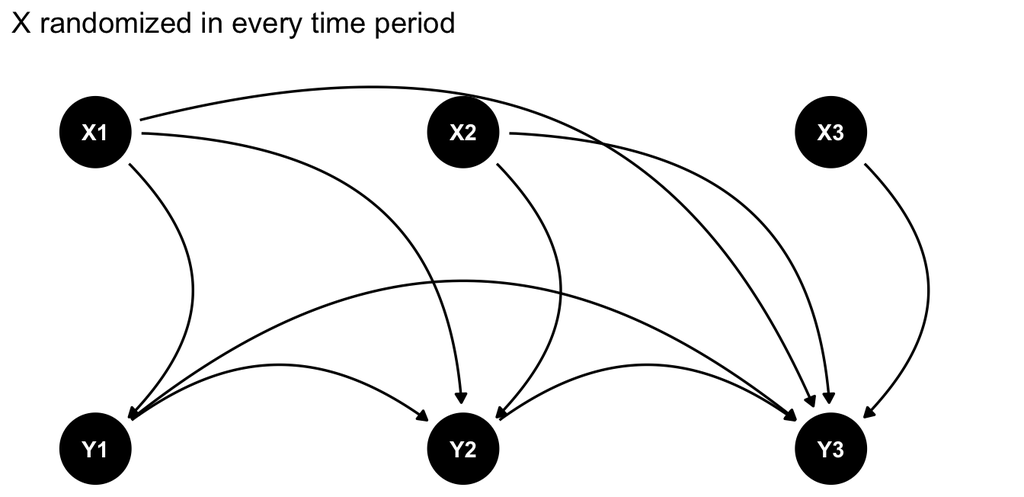

```r
repexdag<-dagify(Y3~X3+Y2+X2+Y1+X1,Y2~X2+Y1+X1,Y1~X1) #create graph
#Set position of nodes so they lie on a straight line
  coords<-list(x=c(X1 = 0, Y1 = 0, X2=1, Y2=1, X3=2, Y3=2),
               y=c(X1 = 1, Y1 = 0, X2=1, Y2=0, X3=1, Y3=0))
  coords_df<-coords2df(coords)
  coordinates(repexdag)<-coords2list(coords_df)
ggdag(repexdag, edge_type = "arc")+theme_dag_blank()+ggplot2::labs(title="X randomized in every time period") #Plot causal graph
```

- **Corollary** to decomposition: If $X_{k,t}\perp(\{Y_{t+h}^{x_{1:t+h}}\ \forall x_{1:t+h}\},X_{1:t-1},(X_{1,t},\ldots,x_k,\ldots,X_{d_x,t}),X_{t+1:t+h})$
  - then $Cov(Y_{t+h}^{(x_k)},1\{X_{k,t}=x_k\})=Cov(Y_{t+h}^{(x_k^\prime)},1\{X_{k,t}=x_k^\prime\})=0$
  - and $E[Y_{t+h}|X_{k,t}=x_k]-E[Y_{t+h}|X_{k,t}=x_k^\prime]$ equals the IRF $E[Y_{t+h}^{(x_k)}-Y_{t+h}^{(x_k^\prime)}]$
- Independence of the treatment at time $t$ and the potential outcomes *as well as* the rest of the treatment process
  - Can verify that this is implied by DAG for repeated experiment structure above
- Absence of past *or future* interactions makes direct conditional mean estimation possible
- Variables $X_t$ with this property sometimes called *structural shocks*
  - Rarely observed directly, but sometimes used as building block to construct model of observed variables
  - If a shock can be isolated, it can be used to measure sequence of responses

## Generalized IRFs

- Consider **Generalized IRF** $GIRF_{k,t,h}(x_k,x_k^\prime|X^{t-1},Y^{t-1}):=E[Y_{t+h}|X_{k,t}=x_k,X^{t-1},Y^{t-1}]-E[Y_{t+h}|X_{k,t}=x_k^\prime,X^{t-1},Y^{t-1}]$
- By conditional version of above proof, it equals (Rambachan and Shephard (2021) Thm 4) $E[Y_{t+h}^{(x_k)}-Y_{t+h}^{(x_k^\prime)}|X^{t-1},Y^{t-1}]+\frac{Cov(Y_{t+h}^{(x_k)},1\{X_{k,t}=x_k\}|X^{t-1},Y^{t-1})}{E[1\{X_{k,t}=x_k\}|X^{t-1},Y^{t-1}]}-\frac{Cov(Y_{t+h}^{(x_k^\prime)},1\{X_{k,t}=x_k^\prime\}|X^{t-1},Y^{t-1})}{E[1\{X_{k,t}=x_k^\prime\}|X^{t-1},Y^{t-1}]}$
- **Corollary**: If $X_{k,t}\perp(\{Y_{t+h}^{x_{1:t}^{observed},x_{t:t+h}}\ \forall x_{t:t+h}\},(X_{1,t},\ldots,x_k,\ldots,X_{d_x,t}),X_{t+1:t+h})|X^{t-1},Y^{t-1}$, the generalized IRF is $E[Y_{t+h}^{(x_k)}-Y_{t+h}^{(x_k^\prime)}|X^{t-1},Y^{t-1}]$
- Its average equals the (unconditional) IRF $E[Y_{t+h}^{(x_k)}-Y_{t+h}^{(x_k^\prime)}]$
- Interpretation: If conditional on past, treatment is independent of potential outcomes and *future assignments*, adjustment estimator controlling for history measures causal effect
  - While slightly weaker than above, this condition will fail if assignments depend on past outcomes or decisions
  - It will hold in repeated experiment setting, where treatments are shocks
- Generalized IRF is a measure which allows heterogeneous and nonlinear effects of shocks
  - Compute in nonlinear structural dynamic models to summarize effects of shocks

## Sequential Conditional Random Assignment

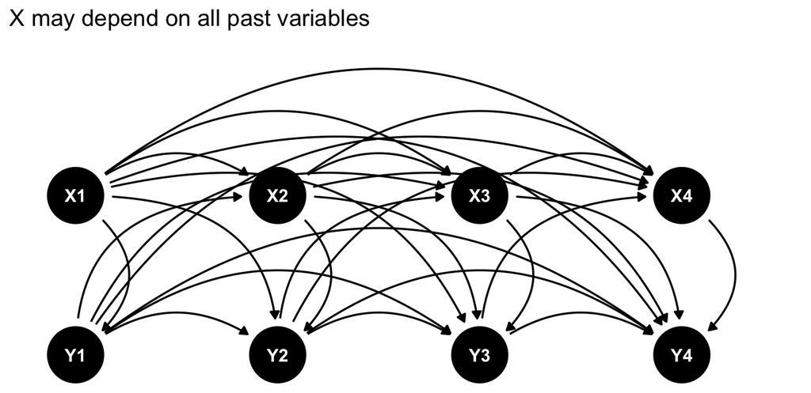

```r
seqdag<-dagify(Y4~X4+Y3+X3+Y2+X2+Y1+X1,Y3~X3+Y2+X2+Y1+X1,Y2~X2+Y1+X1,Y1~X1,
                 X4~Y3+X3+Y2+X2+Y1+X1,X3~Y2+X2+Y1+X1, X2~Y1+X1) #create graph
#Set position of nodes so they lie on a straight line
  coords<-list(x=c(X1 = 0, Y1 = 0, X2=1, Y2=1, X3=2, Y3=2, X4=3, Y4=3),
               y=c(X1 = 1, Y1 = 0, X2=1, Y2=0, X3=1, Y3=0, X4=1, Y4=0))
  coords_df<-coords2df(coords)
  coordinates(seqdag)<-coords2list(coords_df)
ggdag(seqdag, edge_type = "arc")+theme_dag_blank()+ggplot2::labs(title="X may depend on all past variables") #Plot causal graph
```

- Outside of (natural) experiments, treatment assignment generally depends on history of the system
  - In time series, this means dependence on history of both treatment and outcome values
- Causal effect of a change in $X_t$ includes changes in both outcomes and future assignments
- $Y_{t+h}|do(X_t=x)$ corresponds to $Y_{t+h}^{x_t}:=Y_{t+h}^{X_{1:t-1},x_t,X^{x_t}_{t+1:t+h}}$: contains impact of current treatment change, as well as of changes in $X_{t+j}^{X_t}$
- If this is object of interest and relevant history is observed, one can account for the assignment process by applying adjustment
- Assuming conditional ignorability $\{Y_{t+h}^{x_t}\ \forall x_t\}\perp X_t|X^{t-1},Y^{t-1}$, $GIRF_{k,t,h}(x_k,x_k^\prime|X^{t-1},Y^{t-1})= E[Y_{t+h}^{x_t}-Y_{t+h}^{x_t^\prime}|X^{t-1},Y^{t-1}]$
  - Adding overlap, $E[GIRF_{k,t,h}(x_k,x_k^\prime|X^{t-1},Y^{t-1})]=E[Y_{t+h}^{x_k}-Y_{t+h}^{x_k^\prime}]$
  - Proof analogous to cross-sectional case
- Adjustment measures a form of IRF which contains outcome *and* policy responses to treatment
  - If monetary policy mistakes followed by subsequent reversals, measures effect of mistake and reversal on outcomes

## Verifying Conditional Random Assignment

- Helpful trick for verifying conditions: Single World Intervention Graphs or **SWIG** (Richardson and Robins (2013))
- Tool for verifying relationships between observed and potential outcomes by putting them on the same graph
- Idea: “do” operation represented by splitting node into observed and counterfactual outcome
  - Inward arrows point to observed half, outward from counterfactual half
  - Descendants of split node are counterfactuals
- Because graph obeys Markov property, d-separation guarantees conditional independence between observed and counterfactual outcomes
  - Can verify, eg $Y^x\perp X | Z$ by $(Y^x\perp X | Z)_G$
- Following SWIG shows that conditional random assignment holds in sequential setting

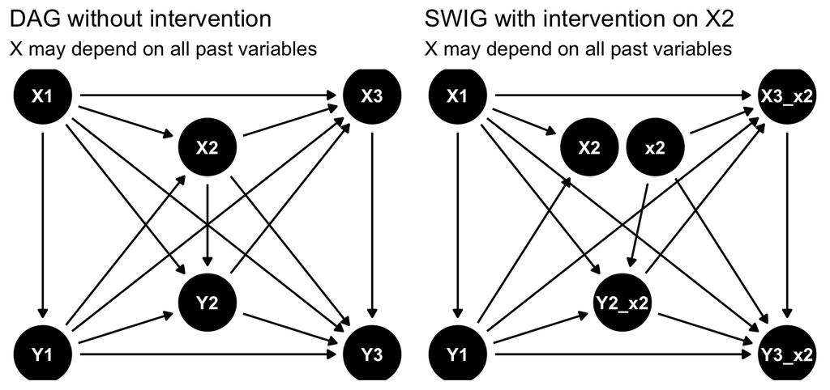

```r
library(gridExtra) #Graph Display
splitgraphs<-list()
predag<-dagify(Y3~X3+Y2+X2+Y1+X1,Y2~X2+Y1+X1,Y1~X1,
                 X3~Y2+X2+Y1+X1, X2~Y1+X1) #create graph
#Set position of nodes so they lie on a straight line
  coords<-list(x=c(X1 = 0, Y1 = 0, X2=1, Y2=1, X3=2, Y3=2),
               y=c(X1 = 1, Y1 = 0, X2=0.8, Y2=0.2, X3=1, Y3=0))
  coords_df<-coords2df(coords)
  coordinates(predag)<-coords2list(coords_df)
splitgraphs[[1]]<-ggdag(predag)+theme_dag_blank()+ggplot2::labs(title="DAG without intervention",subtitle="X may depend on all past variables") #Plot causal graph


swig<-dagify(Y3_x2~X3_x2+Y2_x2+x2+Y1+X1,Y2_x2~x2+Y1+X1,Y1~X1,
                 X3_x2~Y2_x2+x2+Y1+X1, X2~Y1+X1) #create graph
#Set position of nodes so they lie on a straight line
  coords<-list(x=c(X1 = 0, Y1 = 0, X2=0.8, x2=1.2, Y2_x2=1, X3_x2=2, Y3_x2=2),
               y=c(X1 = 1, Y1 = 0, X2=0.8, x2=0.8, Y2_x2=0.2, X3_x2=1, Y3_x2=0))
  coords_df<-coords2df(coords)
  coordinates(swig)<-coords2list(coords_df)
splitgraphs[[2]]<-ggdag(swig)+theme_dag_blank()+ggplot2::labs(title="SWIG with intervention on X2",subtitle="X may depend on all past variables") #Plot causal graph

grid.arrange(grobs=splitgraphs,nrow=1,ncol=2) #Arrange In 2x2 grid
```

```r
#Test that effect of X2 on Y2, Y3 identifiable by adjustment
dseparated(swig,c("Y3_x2","Y2_x2"),"X2",c("Y1","X1"))
```

```
## [1] TRUE
```

## What needs to be controlled for? An aside on expectations

- Economic reasoning can help suggest causal links
- A forward-looking decision-maker who cares about the outcome will use *expectations* of future outcomes to determine actions
- Any *past* variable known to the decision-maker which predicts the outcome within the planning horizon can impact their predictions and so decisions
- This means it is hard to exclude any past observables from the adjustment set, particularly for widely reported macroeconomic and financial variables
  - This is common justification for including entire past history as set of adjustment variables
  - It also means that sources of information that are *not* accounted for may act as confounders: treatment may be responding to news about developments affecting outcome, rather than outcome responding to treatment
  - Common to use info from asset prices (Kuttner (2001), Nakamura and Steinsson (2018)), official forecasts, surveys, and media, as well as large databases of macroeconomic variables (Bernanke, Boivin, and Eliasz (2005)), to account for these factors
- The *rational expectations* modeling framework derives decision-maker expectations from the model-implied law of the data, and optimization describes the form of the impact of these expectations on decisions
- These assumptions may help suggest covariates and functional forms, but are *not needed* when applying non- or semi-parametric inference methods
  - Pure optimization as a model is also inconsistent with *overlap* unless decisions exhibit idiosyncratic variability due to e.g. mistakes, taste changes, or misperceptions

## Markovian Sequential Conditional Random Assignment

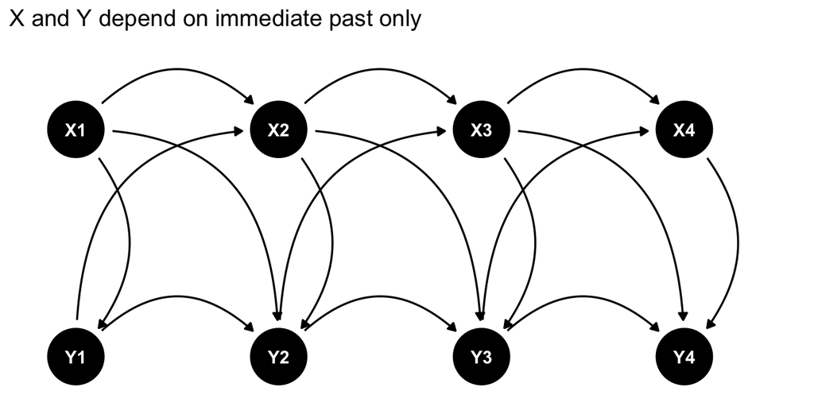

```r
markovdag<-dagify(Y4~X4+Y3+X3,Y3~X3+Y2+X2,Y2~X2+Y1+X1,Y1~X1,
                 X4~Y3+X3,X3~Y2+X2, X2~Y1+X1) #create graph
#Set position of nodes so they lie on a straight line
  coords<-list(x=c(X1 = 0, Y1 = 0, X2=1, Y2=1, X3=2, Y3=2, X4=3, Y4=3),
               y=c(X1 = 1, Y1 = 0, X2=1, Y2=0, X3=1, Y3=0, X4=1, Y4=0))
  coords_df<-coords2df(coords)
  coordinates(markovdag)<-coords2list(coords_df)
ggdag(markovdag, edge_type = "arc")+theme_dag_blank()+ggplot2::labs(title="X and Y depend on immediate past only") #Plot causal graph
```

- As a common simplification, it is often assumed that causal structure is **recursive**
  - $(O_{t+1}\perp O^{t-1}|O_t)_{G}$ state variables in time $t$ d-separate future from past
  - This implies probability distribution is also (first order) Markov: $P(O_{t+1}|O^{t})=P(O_{t+1}|O_{t})$
- This simplifies analysis enormously, and is the basis for huge fraction of dynamic economic modeling (Ljungqvist and Sargent (2018), Stokey, Lucas, and Prescott (1989))
- Conditional ignorability can be truncated to $\{Y_{t+h}^{x_t}\ \forall x_t\}\perp X_t|X_{t-1},Y_{t-1}$ and $GIRF_{k,t,h}(x_k,x_k^\prime|X_{t-1},Y_{t-1})= E[Y_{t+h}^{x_t}-Y_{t+h}^{x_t^\prime}|X_{t-1},Y_{t-1}]$
  - Adding overlap, $E[GIRF_{k,t,h}(x_k,x_k^\prime|X_{t-1},Y_{t-1})]=E[Y_{t+h}^{x_k}-Y_{t+h}^{x_k^\prime}]$
- Restriction to one period dependence can be extended to $k$ periods by adjusting state space
  - Redefine $\tilde{O}_t=(O_t,O_{t-1},\ldots,O_{t-k})$, then conditional law of motion for first element is unchanged, and the lags shift up by 1 each period

## Estimation

- In case that probability of assignment known, can construct *unbiased* estimator with repeated random or conditionally random assignment by inverse propensity weighting
  - $E[\frac{1\{X_{t,k}=x_k\}}{P(X_{t,k}=x_k|X^{t-1},Y^{t-1})}Y_{t+h}]=E[Y_{t+h}|X_{t,k}=x_k,X^{t-1},Y^{t-1}]$
- Without stationarity, effects of time $t$ intervention need not be the same as those at other times, but you can aggregate to get a measure of sample average treatment effect
  - $\frac{1}{T-h}\sum_{t=1}^{T-h}\frac{1\{X_{t,k}=x_k\}}{P(X_{t,k}=x_k|X^{t-1},Y^{t-1})}Y_{t+h}$ is unbiased estimate of $\frac{1}{T-h}\sum_{t=1}^{T-h}E[Y_{t+h}|X_{t,k}=x_k,X^{t-1},Y^{t-1}]$
- With stationarity of $\{X_t,\{Y_t^{x_{1:t}}\ \forall x_{1:t}\}\}_{t=1}^{T}$, it is unbiased estimate of the population average treatment effect
- To get consistency and asymptotic normality, add ergodicity, strong mixing, and finite conditional variances of the summands
  - This is a slightly more delicate question than that of the time $t$ variables, because conditioning on the past induces additional dependence
  - In the finite order Markovian case, it goes through by bounding mixing of lagged variables
- In infinite order case, need additional limited *causal* dependence conditions: propensity can’t depend too strongly on far past
  - Presence of $X_{t-k}$ in rule induces direct correlation with observation $k$ periods away, so need size of impact small to bound covariance

## Modeling Assignment and Outcomes

- In case where propensity score is unknown, it can be estimated, e.g. by probit/logit or other parametric model
  - Angrist, Jordà, and Kuersteiner (2018) provide asymptotics under stationarity and mixing conditions
- Alternately, estimate difference in conditional means directly
  - Linear regression of $Y_{t+h}$ on $X_{t,k}$, possibly with controls is called a **Local projection** estimator
  - Ramey (2016) gives background and applications
  - Rambachan and Shephard (2021) show that in absence of linearity or homogeneity, it estimates weighted average of treatment effects
- Nothing is stopping you from running the AIPW estimator, $\frac{1}{T-h}\sum_{t=1}^{T-h}(\widehat{E}[Y_{t+h}|x_{t,k},X^{t-1},Y^{t-1}]+\frac{1\{X_{t,k}=x_k\}}{\widehat{P}(X_{t,k}=x_k|X^{t-1},Y^{t-1})}(Y_{t+h}-\widehat{E}[Y_{t+h}|x_{t,k},X^{t-1},Y^{t-1}]))$
  - Literature on it in time series series setting appears sparse (Kato et al. (2021), Waudby-Smith et al. (2021) apply it in sequential settings, but not under weak dependent data setting relevant to observational time series)
  - Easy to verify it remains doubly robust in sense that identification formula holds given either correctly specified mean or propensity model
  - Cross-fitting for mixing time series can be done by splitting in blocks of ordered observations $O_{1:T/3},O_{T/3+1:2T/3},O_{2T/3+1:T}$, discarding the middle block, and using the 1st and 3rd and 3rd and 1st for nuisances and final estimates, respectively
  - Discarding the middle block ensures near-independence under mixing, at cost of losing samples: can tune block sizes more finely if faster mixing known or suspected

## Illustration: Monetary Policy Effects

- Angrist, Jordà, and Kuersteiner (2018) uses IPW to estimate effect of Fed Funds Rate on economic variables like Industrial Production (IP)
- Use Fed Funds Futures and past rates and aggregates to give incorporate market predictions into assignment rule
- Time series of propensity score and outcomes shows periods associated with *predicted* rise or fall in rates

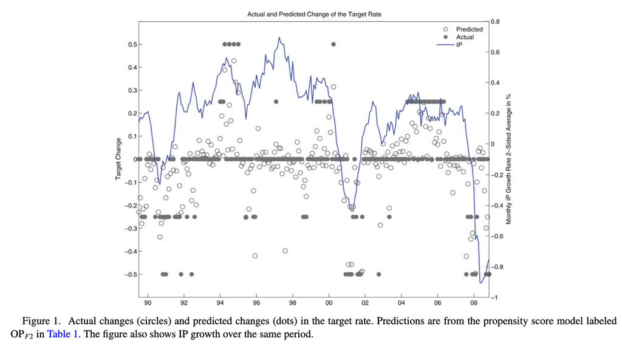

Propensity Time Series

## Angrist, Jordà, and Kuersteiner (2018) Results

- Resulting IRF estimates show asymmetric effects for rate increases and decreases, as IPW does not impose a functional form on the outcome model
  - Direction of effects is consistent with conventional wisdom, but greater impact of increases as opposed to decreases not measurable with linear methods

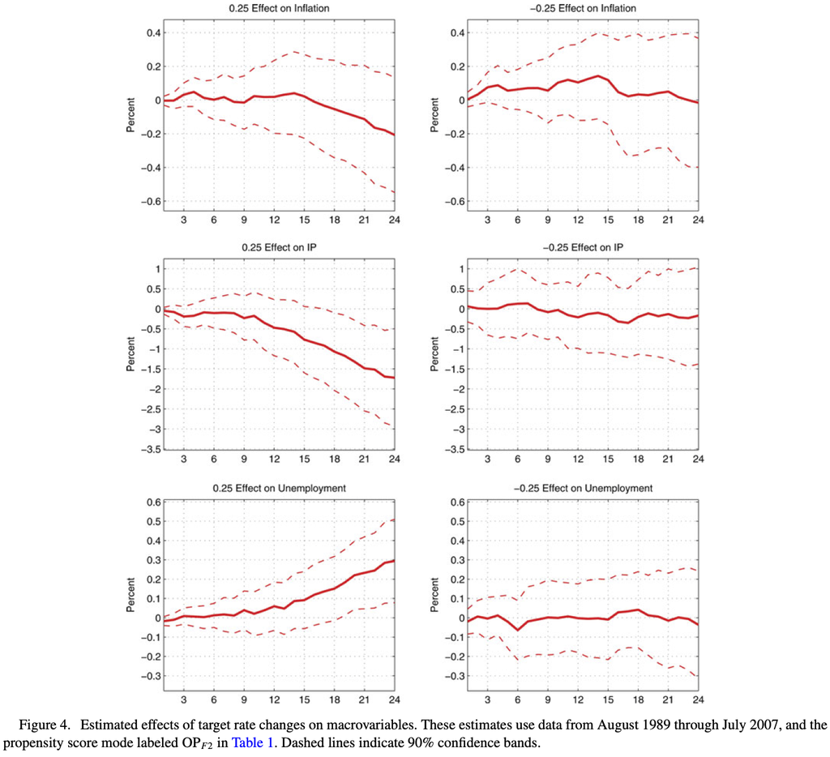

Impulse Response Functions

## Linear Estimators: Local Projections and VARs

- **Local Projection**: linear regression of $Y_{t+h}$ on $X_t$ for each $h$, possibly with controls, is transparent way to estimate an IRF
- Earlier work, dating back to Sims (1980) took a different approach, based on modeling the full probability distribution
- A *Vector Autoregression* or **VAR** is a regression of each element of a vector $O_t=(O_{1,t},O_{2,t},...,O_{d_o,t})^{\prime}$ on its lagged values
  - $O_t=\sum_{p=1}^{P}A_pO_{t-p}+u_t$, where $A_p$ is a $d_o\times d_o$ matrix of coefficients and $u_t\in\mathbb{R}^{d_o}$ is a vector of possibly correlated error terms
  - Estimate equation by equation with OLS, jointly by GMM or MLE, or apply Bayesian method with priors
- If there is a contemporaneous relationship between variables in $O_t$, in addition to a (P-th order Markov) relationship to past values
  - Then structural equation representation of the model is $O_{j,t}=f(O_{-j,t},\{O_{t-p}\}_{p=1}^{P},e_{j,t})$ for each $j=1\ldots d_o$
  - Under linearity, the system can be written as $O_t=\sum_{p=0}^{P}B_pO_{t-p}+e_t$
- Moving $B_0O_t$ to the other side obtain the *Structural VAR* or **SVAR** representation of system $(I-B_0)O_t=\sum_{p=1}^{P}B_pO_{t-p}+e_t$
- Assuming *acyclic* contemporaneous relationships, there exists an ordering of the variables such that $B_0$ is lower triangular and $(I-B_0)$ invertible
  - $O_t=\sum_{p=1}^{P}(I-B_0)^{-1}B_pO_{t-p}+(I-B_0)^{-1}e_t$ so $A_p=(I-B_0)^{-1}B_p$
- If errors $e_{j,t}$ are mutually independent with variance $\sigma_j^2$, $Var(u_t)=(I-B_0)^{-1}\Sigma(I-B_0)^{\prime-1}$ for diagonal $(\Sigma)_{jj}=\sigma^2_{j}$
  - Since $(I-B_0)^{-1}$ triangular, can recover $(I-B_0)^{-1}\Sigma^{1/2}$ from **Cholesky** decomposition of $Var(u_t)$
  - Identifies full system up to magnitude of shock (can normalize to 1) if causal order known
- To obtain IRF to $e_j$, $IRF_0=(I-B_0)^{-1}\Sigma^{1/2}$ gives immediate impact, and $IRF_h=\sum_{s=1}^{\min(h,P)}A_sIRF_{h-s}$

## LP vs VAR IRFs

- Focus on effect of “shocks” rather than of variables has led to many proposals for identifying shocks other than the Cholesky ordering
  - Some of these can be derived from well-specified structural systems in which a shock is identified with a (possibly latent) variable
  - Others are ad-hoc, in which case the “shock” may not be definable in terms of effect of any particular variable
  - In my view, lack of transparency regarding structural meaning of identifying assumptions has been part of the reason for widespread skepticism of VAR results
- A local projection procedure that recovers the same immediate response as VAR with Cholesky ordering is linear regression of $O_{j,t}$ on $O_{k,t}$ for $O_k$ the time t ancestors of $O_j$, and $\{O_{t-p}\}_{p=1}^{P}$
  - Difference is that coefficient is on $O_k$ instead of $e_k$, the structural error in $O_k$, but these are identical after multiplying the VAR impulse response by the residual standard error of the LP regression (Plagborg-Møller and Wolf (2021) Prop 1)
  - This makes clear that SVAR with Cholesky ordering is relying on backdoor adjustment formula using linear homogeneous mean modeling to estimate $E[Y_{t+h}^{x_k}-Y_{t+h}^{x_k}]$, and should be assessed in the same way
  - In particular, estimates need not be causally interpretable for all variables in a system or even in a single equation
- IRFs for later lags from VAR and LP differ in finite samples, since VAR extrapolates based on fixed lag coefficients
  - However, up to scale and estimation error, effect estimated is the same up to order of included lags, and identical if an unlimited number of lags included
- Choice between LP and VAR should be made based on statistical properties and interpretability (which will depend on audience)
  - Montiel Olea and Plagborg-Møller (2021) suggest LPs have desirable inference properties in case of high persistence
  - Simulations in Li, Plagborg-Møller, and Wolf (2021) show either may dominate depending on setting

## Alternate Identification Approaches

- Sequential conditional random assignment permits estimators that generalize adjustment to dynamic settings
- In some cases, can instead apply instrumental variables approach
- If $W_t$ is an external instrument, $X_t$ is treatment and $Y_{t+h}$ is outcome, sequential versions of IV conditions can be shown to estimate a time series version of LATE (Rambachan and Shephard (2021))
  - Exogeneity and exclusion restriction require assignment independent of past and future instruments and treatments, and absence of direct impact on $Y_{t+s}$ for any $0\leq s\leq h$
- Estimation can be done by Local Projection IV estimate (Stock and Watson (2018))
  - Replace OLS by 2SLS estimate of LP equation
  - Linear case is equivalent to ordering $W_t$ IV before $X_t$ and $Y_t$ in Cholesky VAR (Plagborg-Møller and Wolf (2021))
- VAR literature contains variety of other methods for estimating impact of a shock including restrictions based on presence or absence of long run impact of particular variables (Blanchard and Quah (1989)), restrictions on the sign of effects on certain variables (Uhlig (2005)), and others
  - Use of multiple outcomes is reminiscent of strategies based on negative control, but existing presentations for time series heavily rely on parametric forms

## Sequential Exposures

- One important limitation of analyses based on point exposures is that they describe responses only to temporary interventions
  - Change $X_t$ but leave $X_{t+h}$, $h>0$ unmodified, or at value determined by response to treatment
- In linear causal model case, intervention effects are additive, so effects of compound interventions can be recovered from summation of point effects
  - This “sequence space” perspective underlies methods for estimation (Plagborg-Møller (2019)), identification (Wolf (2020), Mckay and Wolf (2021)), and computation (Auclert et al. (2021), Boppart, Krusell, and Mitman (2018)) in recursive linear(ized) macro models
- In general nonlinear case, sequence of treatments $do(X_t=x_0,X_{t+1}=x_1,X_{t+2}=x_2,\ldots,X_{t+k}=x_k)$ is referred to as a *treatment strategy*
  - Effects under any finite strategy are identified under sequential exchangeability $Y_{t+h}^{x_{t:t+k}}\perp X_{t+j} | Z^{t+j}, Y^{t+j-1},X^{t+j-1},$ for each $j$, independence given current controls $Z_{t+j}$ and history of other values $O^{t-1}$ (with overlap for each conditional probability)
- Possibility that treatment affects variables that need to be controlled for for future treatments means that one cannot simply condition on the full path of treatments and sequence of controls
- Estimators available include weighting by inverse of *product* of propensity scores $\Pi_{j=0}^{k}\frac{1}{P(X_{t+j}|Z_{t+j},O^{t+j-1})}$ (Hernán and Robins (2020) Ch 21)
- More generally, may want to measure effect of systematic change in *policy*: a *dynamic treatment regime* changes rule for assigning treatment conditionally on other variables
- Treatment Strategy estimators applicable in that situation as well
- For permanent changes in policy, economists may prefer to use estimates based on full structural dynamic model, which can account for all forms of feedback

## Conclusions

- Time Series structure results in causal and statistical dependence across observtions at different times
- Estimation and inference can be performed under stationarity and weak dependence
- Sequential analogues of random and conditionally random assignment processes allow estimation of *Impulse Response Functions*
- Implementation in the linear case can be done with Local Projections or VARs

## References

Angrist, Joshua D, Òscar Jordà, and Guido M Kuersteiner. 2018. “Semiparametric Estimates of Monetary Policy Effects: String Theory Revisited.” *Journal of Business & Economic Statistics* 36 (3): 371–87.

Auclert, Adrien, Bence Bardóczy, Matthew Rognlie, and Ludwig Straub. 2021. “Using the Sequence-Space Jacobian to Solve and Estimate Heterogeneous-Agent Models.” *Econometrica* 89 (5): 2375–2408.

Bernanke, Ben S, Jean Boivin, and Piotr Eliasz. 2005. “Measuring the Effects of Monetary Policy: A Factor-Augmented Vector Autoregressive (FAVAR) Approach.” *The Quarterly Journal of Economics* 120 (1): 387–422.

Blanchard, OJ, and Danny Quah. 1989. “The Dynamic Effects of Aggregate Demand and Supply Disturbances.” *American Economic Review* 79 (4): 655–73.

Boppart, Timo, Per Krusell, and Kurt Mitman. 2018. “Exploiting MIT Shocks in Heterogeneous-Agent Economies: The Impulse Response as a Numerical Derivative.” *Journal of Economic Dynamics and Control* 89: 68–92. https://doi.org/https://doi.org/10.1016/j.jedc.2018.01.002.

Bradley, Richard C. 2005. “Basic Properties of Strong Mixing Conditions. A Survey and Some Open Questions.” *Probability Surveys* 2: 107–44.

Doukhan, Paul, Pascal Massart, and Emmanuel Rio. 1994. “The Functional Central Limit Theorem for Strongly Mixing Processes.” In *Annales de l’IHP Probabilités Et Statistiques*, 30:63–82. 1.

Hernán, Miguel A, and James M Robins. 2020. “Causal Inference: What If.” Boca Raton: Chapman & Hall/CRC.

Kato, Masahiro, Takuya Ishihara, Junya Honda, and Yusuke Narita. 2021. “Efficient Adaptive Experimental Design for Average Treatment Effect Estimation.” https://arxiv.org/abs/2002.05308.

Kuttner, Kenneth N. 2001. “Monetary Policy Surprises and Interest Rates: Evidence from the Fed Funds Futures Market.” *Journal of Monetary Economics* 47 (3): 523–44.

Lazarus, Eben, Daniel J Lewis, James H Stock, and Mark W Watson. 2018. “HAR Inference: Recommendations for Practice.” *Journal of Business & Economic Statistics* 36 (4): 541–59.

Li, Dake, Mikkel Plagborg-Møller, and Christian K Wolf. 2021. “Local Projections Vs. VARs: Lessons from Thousands of DGPs.” *arXiv Preprint arXiv:2104.00655*.

Ljungqvist, Lars, and Thomas J Sargent. 2018. *Recursive Macroeconomic Theory*. MIT press.

Mckay, Alisdair, and Christian K Wolf. 2021. “What Can Time-Series Regressions Tell Us about Policy Counterfactuals?”

Montiel Olea, José Luis, and Mikkel Plagborg-Møller. 2021. “Local Projection Inference Is Simpler and More Robust Than You Think.” *Econometrica* 89 (4): 1789–1823.

Nakamura, Emi, and Jón Steinsson. 2018. “High-Frequency Identification of Monetary Non-Neutrality: The Information Effect.” *The Quarterly Journal of Economics* 133 (3): 1283–1330.

Newey, Whitney K, and Kenneth D West. 1987. “A Simple, Positive Semi-Definite, Heteroskedasticity and Autocorrelation Consistent Covariance Matrix.” *Econometrica: Journal of the Econometric Society*, 703–8.

Plagborg-Møller, Mikkel. 2019. “Bayesian Inference on Structural Impulse Response Functions.” *Quantitative Economics* 10 (1): 145–84.

Plagborg-Møller, Mikkel, and Christian K Wolf. 2021. “Local Projections and VARs Estimate the Same Impulse Responses.” *Econometrica* 89 (2): 955–80.

Rambachan, Ashesh, and Neil Shephard. 2021. “When Do Common Time Series Estimands Have Nonparametric Causal Meaning?” https://scholar.harvard.edu/shephard/publications/nonparametric-dynamic-causal-model-macroeconometrics.

Ramey, Valerie A. 2016. “Macroeconomic Shocks and Their Propagation.” *Handbook of Macroeconomics* 2: 71–162.

Richardson, Thomas S, and James M Robins. 2013. “Single World Intervention Graphs (SWIGs): A Unification of the Counterfactual and Graphical Approaches to Causality.” *Center for the Statistics and the Social Sciences, University of Washington Series. Working Paper* 128 (30): 2013.

Sims, Christopher A. 1980. “Macroeconomics and Reality.” *Econometrica: Journal of the Econometric Society*, 1–48.

Stock, James H, and Mark W Watson. 2018. “Identification and Estimation of Dynamic Causal Effects in Macroeconomics Using External Instruments.” *The Economic Journal* 128 (610): 917–48.

Stokey, Nancy L, Robert Lucas, and Ed Prescott. 1989. *Recursive Methods in Economic Dynamics*. Harvard University Press.

Uhlig, Harald. 2005. “What Are the Effects of Monetary Policy on Output? Results from an Agnostic Identification Procedure.” *Journal of Monetary Economics* 52 (2): 381–419.

Waudby-Smith, Ian, David Arbour, Ritwik Sinha, Edward H. Kennedy, and Aaditya Ramdas. 2021. “Doubly Robust Confidence Sequences for Sequential Causal Inference.” https://arxiv.org/abs/2103.06476.

Wolf, Christian K. 2020. “The Missing Intercept: A Demand Equivalence Approach.”